# Transportation Cost County

Author

Tina Chelidze

Published

April 9, 2024

*2023-2024 Mobility Metrics update*

SUMMARY-LEVEL VALUES

Raw data pulled from https://htaindex.cnt.org/download/ The Housing and Transportation (H+T) Affordability Index from the Center for Neighborhood Technology (CNT)

*User Notice: This program requires downloading raw files from the Metrics_2024_round Box folder prior to running. See details under the Read Data section.*

## Housekeeping

Read in packages for use.

```r
library(tidyr)
library(dplyr)
library(readr)
library(ggplot2)
library(tidyverse)
library(purrr)
```

## Read data

- htaindex2015_data_counties.csv
- htaindex2019_data_counties.csv

Import all the files (and/or combine into one file) with only the relevant variables and years

FOR COUNTIES - import the raw data files

Unlike for Places and Tracts, the CNT website allows you to download raw data for all counties at once so we just import the all-county file for the two available years; 2015 and 2019

### 2015

```r
transport_county_2015 <- read_csv(here::here("06_neighborhoods",
                                             "Transportation",
                                             "data",
                                             "htaindex2015_data_counties.csv"))
```

create correct FIPS columns

```r
transport_county_2015 <- transport_county_2015 %>%
  mutate(
    state = substr(county, start = 2, stop = 3),
    county = substr(county, start = 4, stop = 6)
  )
```

keep only variables of interest

```r
transportation_cost_county_2015 <- transport_county_2015 %>%
  select(state, county, blkgrps, population, households, t_80ami)
```

### 2019

```r
transport_county_2019 <- read_csv(here::here("06_neighborhoods",
                                             "Transportation",
                                             "data",
                                             "htaindex2019_data_counties.csv"))


transport_county_2019 <- transport_county_2019 %>%
  select(county, blkgrps, population, households, t_80ami)
```

create correct FIPS columns

```r
transport_county_2019 <- transport_county_2019 %>%
  mutate(
    state = substr(county, start = 2, stop = 3),
    county = substr(county, start = 4, stop = 6)
  )
```

Keep only variables of interest

```r
transportation_cost_county_2019 <- transport_county_2019 %>%
  select(state, county, blkgrps, population, households, t_80ami)
```

Compare to our official county file to make sure we have all counties accounted for

Bring in the official county file you should already be in the project folder for this path to work

```r
counties <- read_csv(here::here("geographic-crosswalks",
                                "data",
                                "county-populations.csv"))

counties_2015 <- counties %>%
  filter(year == 2015)

counties_2019 <- counties %>%
  filter(year == 2019)
```

All files have same number of observations (3142) so no merging needed to account for missings!

## QC Checks

Create a histogram plot and summary stats for each dataframe check that all values are non-negative & count missing values examine outliers

County-Level Transportation Cost 2015

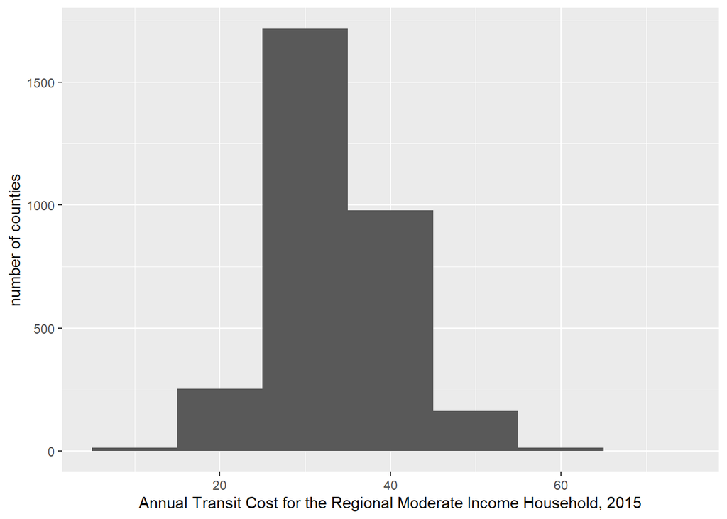

```r
ggplot(transportation_cost_county_2015, aes(x=t_80ami)) + geom_histogram(binwidth=10) + labs(y="number of counties", x="Annual Transit Cost for the Regional Moderate Income Household, 2015")
```

Look at summary stats

```r
summary(transportation_cost_county_2015$t_80ami)
```

```
   Min. 1st Qu.  Median    Mean 3rd Qu.    Max.    NA's
   5.00   30.00   34.00   34.13   38.00   67.00       1
```

Examine outliers

```r
transportation_cost_county_2015_outliers <- transportation_cost_county_2015 %>%
  filter(t_80ami>100)
```

No weird outliers

Use stopifnot to check if all values in “transportation_cost_county_2015” are non-negative

```r
stopifnot(min(transportation_cost_county_2015$t_80ami, na.rm = TRUE) >= 0)
```

Good to go.

Find indices of missing values for the “t_80ami” variable.

```r
missing_indices <- which(is.na(transportation_cost_county_2015$t_80ami))
```

Print observations with missing values

```r
if (length(missing_indices) > 0) {
  cat("Observations with missing values for transit_cost_80ami:\n")
  print(transportation_cost_county_2015[missing_indices, , drop = FALSE])
} else {
  cat("No missing values for transportation_cost_county_2015\n")
}
```

```
Observations with missing values for transit_cost_80ami:
# A tibble: 1 × 6
  state county blkgrps population households t_80ami
  <chr> <chr>    <dbl>      <dbl>      <dbl>   <dbl>
1 48    301          1        117         45      NA
```

1 missing value: Loving County, TX (48301 FIPS).

County-Level Transportation Cost 2019

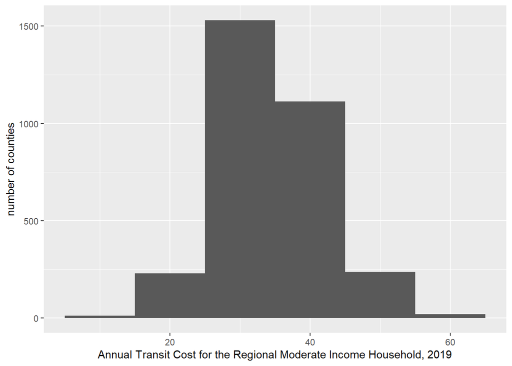

```r
ggplot(transportation_cost_county_2019, aes(x=t_80ami)) + geom_histogram(binwidth=10) + labs(y="number of counties", x="Annual Transit Cost for the Regional Moderate Income Household, 2019")
```

Look at summary stats

```r
summary(transportation_cost_county_2019$t_80ami)
```

```
   Min. 1st Qu.  Median    Mean 3rd Qu.    Max.
   8.00   31.00   34.00   35.04   39.00   63.00
```

Examine outliers

```r
transportation_cost_county_2019_outliers <- transportation_cost_county_2019 %>%
  filter(t_80ami>100)
```

No weird outliers

Use stopifnot to check if all values in “transportation_cost_county_2019” are non-negative

```r
stopifnot(min(transportation_cost_county_2019$t_80ami, na.rm = TRUE) >= 0)
```

Good to go.

Find indices of missing values for the “transit_cost_80ami” variable

```r
missing_indices <- which(is.na(transportation_cost_county_2019$t_80ami))
```

Print observations with missing values

```r
if (length(missing_indices) > 0) {
  cat("Observations with missing values for transit_cost_80ami:\n")
  print(transportation_cost_county_2019[missing_indices, , drop = FALSE])
} else {
  cat("No missing values for transportation_cost_county_2019\n")
}
```

```
No missing values for transportation_cost_county_2019
```

No missing values for 2019.

## Data quality marker

Determine data quality cutoffs based on number of observations (all at the HH level for these values)

```r
summary(transportation_cost_county_2015$households)
```

```
   Min. 1st Qu.  Median    Mean 3rd Qu.    Max.
     45    4232    9808   37214   25607 3263069
```

```r
summary(transportation_cost_county_2019$households)
```

```
   Min. 1st Qu.  Median    Mean 3rd Qu.    Max.
     30    4268    9928   38433   26042 3316795
```

We use a 30 HH cutoff for Data Quality 3 for the ACS variables, so for the sake of consistency, since none of these are less than 30 (all minimum values are at least 30 HHs), Data Quality can be 1 for all these observations BUT ALSO, rename all the metrics variables to what we had before (transit_trips & transit_cost), so we can name the quality variable appropriately

```r
transportation_cost_county_2015 <- transportation_cost_county_2015 %>%
  rename(transit_cost = t_80ami) %>%
  mutate(transit_cost_quality = 1)
transportation_cost_county_2019 <- transportation_cost_county_2019 %>%
  rename(transit_cost = t_80ami) %>%
  mutate(transit_cost_quality = 1)
```

## Export files

Add a variable for the year of the data

```r
transportation_cost_county_2015 <- transportation_cost_county_2015 %>%
  mutate(
    year = 2015
  )
```

```r
transportation_cost_county_2019 <- transportation_cost_county_2019 %>%
  mutate(
    year = 2019
  )
```

Combine the two years into one overall files for both variables

```r
transit_cost_county <- rbind(transportation_cost_county_2015, transportation_cost_county_2019)
```

Keep variables of interest and order them appropriately also rename to correct var names

```r
transit_cost_county <- transit_cost_county %>%
  rename(index_transportation_cost = transit_cost,
         index_transportation_cost_quality = transit_cost_quality) %>%
  select(year, state, county, index_transportation_cost, index_transportation_cost_quality) %>%
  arrange(year, state, county, index_transportation_cost, index_transportation_cost_quality)
```

Save as non-subgroup all-year files.

```r
write_csv(transit_cost_county, here::here("06_neighborhoods",
                                          "Transportation",
                                          "final",
                                          "transit_cost_all_county.csv"))
```